# Reglas de Asociación

Implementación con arules en R  
Juan Manuel Fernandez

### Contenidos

En esta clase vamos a trabajar con reglas de asociación en R:

- El objeto **transactions**: lectura, casteo y utilización.
- Generación de reglas de asociación.
- Inspección y evaluación de reglas.
- Filtrado de reglas.

### Dataset para la demostración

Para los ejemplos de esta presentación vamos a utilizar el dataset Groceries del paquete arules:

```r
library(arules)
data(Groceries)

Groceries
```

```
transactions in sparse format with
 9835 transactions (rows) and
 169 items (columns)
```

Como vemos, Groceries es de tipo **transactions**. La documentación de la clase está aquí:

- https://www.rdocumentation.org/packages/arules/versions/1.6-8/topics/transactions-class
- https://cran.r-project.org/web/packages/arules/vignettes/arules.pdf

### El objeto transactions en R

La clase **transactions** representa transacciones utilizadas para el minado de itemsets o reglas (según documentación oficial).

```r
inspect(head(Groceries, 3))
```

```
    items
[1] {citrus fruit,
     semi-finished bread,
     margarine,
     ready soups}
[2] {tropical fruit,
     yogurt,
     coffee}
[3] {whole milk}
```

### El objeto transactions en R (++)

Podemos hacer un **summary** del objeto transactions:

```r
resumen = summary(Groceries)

resumen
```

```
transactions as itemMatrix in sparse format with
 9835 rows (elements/itemsets/transactions) and
 169 columns (items) and a density of 0.02609146

most frequent items:
      whole milk other vegetables       rolls/buns             soda
            2513             1903             1809             1715
          yogurt          (Other)
            1372            34055

element (itemset/transaction) length distribution:
sizes
   1    2    3    4    5    6    7    8    9   10   11   12   13   14   15   16
2159 1643 1299 1005  855  645  545  438  350  246  182  117   78   77   55   46
  17   18   19   20   21   22   23   24   26   27   28   29   32
  29   14   14    9   11    4    6    1    1    1    1    3    1

   Min. 1st Qu.  Median    Mean 3rd Qu.    Max.
  1.000   2.000   3.000   4.409   6.000  32.000

includes extended item information - examples:
       labels  level2           level1
1 frankfurter sausage meat and sausage
2     sausage sausage meat and sausage
3  liver loaf sausage meat and sausage
```

### El objeto transactions en R (+++)

Podemos acceder a las dimensiones del summary de a una con **@**:

```r
resumen@Dim
```

```
[1] 9835  169
```

```r
resumen@density
```

```
[1] 0.02609146
```

```r
resumen@itemSummary
```

```
      whole milk other vegetables       rolls/buns             soda
            2513             1903             1809             1715
          yogurt          (Other)
            1372            34055
```

### El objeto transactions en R (+++)

Podemos acceder a las dimensiones del summary de a una con **@**:

```r
resumen@lengths
```

```
sizes
   1    2    3    4    5    6    7    8    9   10   11   12   13   14   15   16
2159 1643 1299 1005  855  645  545  438  350  246  182  117   78   77   55   46
  17   18   19   20   21   22   23   24   26   27   28   29   32
  29   14   14    9   11    4    6    1    1    1    1    3    1
```

```r
resumen@lengthSummary
```

```
   Min. 1st Qu.  Median    Mean 3rd Qu.    Max.
  1.000   2.000   3.000   4.409   6.000  32.000
```

### Transactions: Casteo de tipos

Podemos generar un objeto transactions a partir de una lista:

```r
canasta <- list( c("cerveza","pañales","chocolate"),
                 c("cerveza","pañales"),
                 c("cerveza","pañales","pan"),
                 c("cerveza","pañales","pan","leche") )

## Equivalntee a canasta_tr = as(canasta, "transactions")
canasta_tr <- transactions(canasta)
canasta_tr
```

```
transactions in sparse format with
 4 transactions (rows) and
 5 items (columns)
```

### Transactions: Casteo de tipos (++)

Resultado del casteo a partir de una lista (instrucción `image(canasta_tr)`):

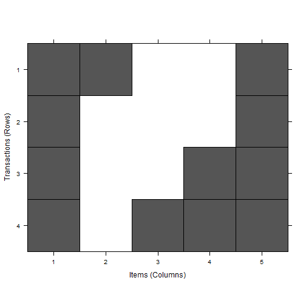

### Transactions: Casteo de tipos (+++)

Podemos generar un objeto transactions a partir de un dataframe:

```r
a_df
```

```
   age grade  pass
1    6     A  TRUE
2    8     C  TRUE
3 <NA>     F FALSE
4    9  <NA>  TRUE
5   16     C  TRUE
```

```r
df_trans <- transactions(a_df)
```

### Transactions: Casteo de tipos (++++)

Verificamos la transformación:

```r
inspect(df_trans)
```

```
    items                 transactionID
[1] {age=6,grade=A,pass}  1
[2] {age=8,grade=C,pass}  2
[3] {grade=F}             3
[4] {age=9,pass}          4
[5] {age=16,grade=C,pass} 5
```

También es posible generar transacciones a partir de otros tipos de datos, como por ejemplo matrices.

### Transactions: Lectura de datos como transactions

La carga y casteo a transacciones para muchos datos puede volverse lento e ineficiente. Es posible cargar directamente transacciones con `read.transactions().` Existen dos tipos: basket (cesta) y single (único).

Para el formato `basket`, cada línea del archivo representa una transacción donde cada item está separado por un caracter especificado en `sep`.

```r
# Guardamos datos para formato basket
data <- paste(
          "item1, item2",
          "item1",
          "item2, item3",
          sep="\n")
write(data, file = "basket.txt")
```

### Transactions: Formato basket

Cargamos los datos de tipo basket:

```r
tr <- read.transactions("basket.txt", format = "basket", sep=",")
inspect(tr)
```

```
    items
[1] {item1,item2}
[2] {item1}
[3] {item2,item3}
```

```r
itemLabels(tr)
```

```
[1] "item1" "item2" "item3"
```

### Transactions: Lectura de datos como transactions (single)

Para el formato `single`, cada línea del archivo corresponde a un item único, el cual contiene el id de la transacción.

```r
# Guardamos datos para formato single

data <- paste(
  "1;item1",
  "1;item2",
  "2;item1",
  "3;item2",
  "3;item3",
  sep ="\n")

write(data, file = "single.txt")
```

### Transactions: Formato single

Cargamos los datos de tipo single:

```r
tr <- read.transactions("single.txt", format = "single", sep = ";", cols = c(1,2))
inspect(tr)
```

```
    items         transactionID
[1] {item1,item2} 1
[2] {item1}       2
[3] {item2,item3} 3
```

```r
itemLabels(tr)
```

```
[1] "item1" "item2" "item3"
```

### Generación de reglas con arules

Una vez que tenemos el objeto transactions, podemos generar las reglas:

```r
# target vistos en clase: "frequent itemsets", "maximally frequent itemsets", "closed frequent itemsets", "rules"

reglas <- apriori(Groceries, parameter = list(support=0.01, confidence=0.01, target = "rules"))
```

```
Apriori

Parameter specification:
 confidence minval smax arem  aval originalSupport maxtime support minlen
       0.01    0.1    1 none FALSE            TRUE       5    0.01      1
 maxlen target  ext
     10  rules TRUE

Algorithmic control:
 filter tree heap memopt load sort verbose
    0.1 TRUE TRUE  FALSE TRUE    2    TRUE

Absolute minimum support count: 98

set item appearances ...[0 item(s)] done [0.00s].
set transactions ...[169 item(s), 9835 transaction(s)] done [0.00s].
sorting and recoding items ... [88 item(s)] done [0.00s].
creating transaction tree ... done [0.00s].
checking subsets of size 1 2 3 4 done [0.00s].
writing ... [610 rule(s)] done [0.00s].
creating S4 object  ... done [0.00s].
```

### Generación de reglas con arules (++)

Algunas instrucciones que podemos aplicar sobre reglas:

```r
resumen = summary(reglas)

resumen@lengths
```

```
sizes
  1   2   3
 88 426  96
```

```r
resumen@length
```

```
[1] 610
```

### Generación de reglas con arules (+++)

```r
resumen@quality
```

```
    support          confidence         coverage            lift
 Min.   :0.01007   Min.   :0.01027   Min.   :0.01729   Min.   :0.7899
 1st Qu.:0.01159   1st Qu.:0.08892   1st Qu.:0.05806   1st Qu.:1.1494
 Median :0.01464   Median :0.15901   Median :0.10493   Median :1.4905
 Mean   :0.02138   Mean   :0.19096   Mean   :0.23668   Mean   :1.5578
 3rd Qu.:0.02227   3rd Qu.:0.26185   3rd Qu.:0.19349   3rd Qu.:1.8338
 Max.   :0.25552   Max.   :0.58621   Max.   :1.00000   Max.   :3.3723
     count
 Min.   :  99.0
 1st Qu.: 114.0
 Median : 144.0
 Mean   : 210.2
 3rd Qu.: 219.0
 Max.   :2513.0
```

### Generación de reglas con arules (++++)

```r
resumen@info
```

```
$data
Groceries

$ntransactions
[1] 9835

$support
[1] 0.01

$confidence
[1] 0.01
```

### Inspección de reglas generadas

Ahora debemos explotar y analizar las reglas:

```r
inspect(reglas[1:2], )
```

```
    lhs    rhs              support    confidence coverage lift count
[1] {}  => {liquor}         0.01108287 0.01108287 1        1    109
[2] {}  => {condensed milk} 0.01026945 0.01026945 1        1    101
```

`lhs`: (left-hand-sides) es la parte izquierda de la regla, o antecedente.  
`rhs`: ( right-hand-sides ) es la parte derecha de la regla, o resultado.  
`Support`: es la frecuencia relativa de una regla sobre el total de transacciones.  
`Confidence`: Mide cuantas veces sucede el rhs cuando se presenta el lhs, para cada regla.  
`Lift`: es la confianza de la regla sobre el soporte del consecuente de la misma.

### Filtrado de reglas generadas

También es posible ejecutar diferentes filtros sobre las reglas, por ejemplo ordenando por lift:

```r
inspect(head(sort(reglas, by="lift", decreasing = TRUE), 3))
```

```
    lhs                                rhs                  support
[1] {whole milk,yogurt}             => {curd}               0.01006609
[2] {citrus fruit,other vegetables} => {root vegetables}    0.01037112
[3] {other vegetables,yogurt}       => {whipped/sour cream} 0.01016777
    confidence coverage   lift     count
[1] 0.1796733  0.05602440 3.372304  99
[2] 0.3591549  0.02887646 3.295045 102
[3] 0.2341920  0.04341637 3.267062 100
```

### Filtrado de reglas generadas (++)

Con `subset`, podemos filtrar por cualquiera de los campos que aparecen en las reglas. Con `%in%` buscamos un producto en concreto.

Por ejemplo, buscamos las que poseen como antecedente -lhs- a la cerveza (bottled beer):

```r
rules.sub <- subset(reglas, subset = lhs %in% "bottled beer")

inspect(rules.sub)
```

```
    lhs               rhs                support    confidence coverage
[1] {bottled beer} => {bottled water}    0.01576004 0.1957071  0.08052872
[2] {bottled beer} => {soda}             0.01698017 0.2108586  0.08052872
[3] {bottled beer} => {rolls/buns}       0.01362481 0.1691919  0.08052872
[4] {bottled beer} => {other vegetables} 0.01616675 0.2007576  0.08052872
[5] {bottled beer} => {whole milk}       0.02043721 0.2537879  0.08052872
    lift      count
[1] 1.7707259 155
[2] 1.2092094 167
[3] 0.9198466 134
[4] 1.0375464 159
[5] 0.9932367 201
```

### Filtrado de reglas generadas (+++)

Además, con `%pin%` podemos buscar en el texto un producto que contenga determinado texto (beer):

```r
rules.sub <- subset(reglas, subset = lhs %pin% "beer")

inspect(rules.sub)
```

```
    lhs               rhs                support    confidence coverage
[1] {canned beer}  => {shopping bags}    0.01138790 0.1465969  0.07768175
[2] {canned beer}  => {soda}             0.01382816 0.1780105  0.07768175
[3] {canned beer}  => {rolls/buns}       0.01128622 0.1452880  0.07768175
[4] {bottled beer} => {bottled water}    0.01576004 0.1957071  0.08052872
[5] {bottled beer} => {soda}             0.01698017 0.2108586  0.08052872
[6] {bottled beer} => {rolls/buns}       0.01362481 0.1691919  0.08052872
[7] {bottled beer} => {other vegetables} 0.01616675 0.2007576  0.08052872
[8] {bottled beer} => {whole milk}       0.02043721 0.2537879  0.08052872
    lift      count
[1] 1.4879052 112
[2] 1.0208356 136
[3] 0.7898878 111
[4] 1.7707259 155
[5] 1.2092094 167
[6] 0.9198466 134
[7] 1.0375464 159
[8] 0.9932367 201
```

### Filtrado de reglas generadas (++++)

También podríamos filtrar por el tamaño del antecedente::

```r
rules.sub <- subset(reglas, subset = size(lhs)==1)

inspect(rules.sub)
```

```
      lhs                           rhs                        support
[1]   {hard cheese}              => {whole milk}               0.01006609
[2]   {whole milk}               => {hard cheese}              0.01006609
[3]   {butter milk}              => {other vegetables}         0.01037112
[4]   {other vegetables}         => {butter milk}              0.01037112
[5]   {butter milk}              => {whole milk}               0.01159126
[6]   {whole milk}               => {butter milk}              0.01159126
[7]   {ham}                      => {whole milk}               0.01148958
[8]   {whole milk}               => {ham}                      0.01148958
[9]   {sliced cheese}            => {whole milk}               0.01077783
[10]  {whole milk}               => {sliced cheese}            0.01077783
[11]  {oil}                      => {whole milk}               0.01128622
[12]  {whole milk}               => {oil}                      0.01128622
[13]  {onions}                   => {other vegetables}         0.01423488
[14]  {other vegetables}         => {onions}                   0.01423488
```

[output cut: 839 more lines]

### Filtrado de reglas generadas (+++++)

A su vez, podemos filtrar por más de una de las condiciones antes vistas:

```r
soda = subset(reglas, subset = rhs %in% "soda" & lift > 1.2)

inspect(head(sort(soda, by="lift", decreasing = TRUE), 3))
```

```
    lhs                rhs    support    confidence coverage   lift     count
[1] {chocolate}     => {soda} 0.01352313 0.2725410  0.04961871 1.562939 133
[2] {bottled water} => {soda} 0.02897814 0.2621895  0.11052364 1.503577 285
[3] {sausage}       => {soda} 0.02430097 0.2586580  0.09395018 1.483324 239
```